# Divergence point analysis

Yiling Huo

2025-08-31

# 1 Preparing data

In this section, we load the data into R, and make them into appropriate format.

## 1.1 Load data

Load R packages.

```r
# Clear workspace if necessary
#rm(list = ls())

# Load packages
library(tidyverse)
library(lme4)
library(boot)
library(polycor)
library(mgcv)
library(Matrix)

# Suppress the `summarise()` regrouping output by 'x' (override with `.groups` argument) message.
options(dplyr.summarise.inform = FALSE)
```

Then, load the eye tracking data, the classifier acceptability data, and the comprehension question accuracy data.

```r
# get today's date
today = as.character(Sys.Date())
# Load the data and the index file
dat_raw <- read.csv(paste("gazedata-merged-fixation-2025-07-02",".csv",sep=''), header = TRUE)
ind <- read.csv("index.csv", header = TRUE)
acc <- read.csv("accuracy-profile.csv", header = TRUE)
```

Exclude participants who scored below 90% in the comprehension questions.

```r
#dat_raw <- droplevels(subset(dat_raw, !(subject %in% c('2024-s01', '2024-s02', '2024-s03'))))

# get by-subject mean accuracy
acc <- aggregate(accuracy ~ subject, data=acc, FUN = mean)
acc
```

```
##     subject  accuracy
## 1  2024-s01 1.0000000
## 2  2024-s02 1.0000000
## 3  2024-s03 0.9545455
## 4  2024-s04 1.0000000
## 5  2024-s05 1.0000000
## 6  2024-s06 1.0000000
## 7  2024-s07 0.9166667
## 8  2024-s08 1.0000000
## 9  2024-s09 1.0000000
## 10 2024-s10 1.0000000
## 11 2024-s11 1.0000000
## 12 2024-s12 0.9166667
## 13 2024-s13 1.0000000
## 14 2024-s14 1.0000000
```

[output cut: 67 more lines]

```r
# get a list of low accuracy subjects
low_accuracy_subjects <- ifelse(acc$accuracy < 0.9, acc$subject, '')
print(c('Low accuracy participants: ', unique(low_accuracy_subjects)))
```

```
## [1] "Low accuracy participants: " ""
## [3] "2025-s16"
```

```r
# remove low accuracy subjects from eye-tracking data
dat_raw <- droplevels(subset(dat_raw, !(subject %in% low_accuracy_subjects)))
dat_raw$subject <- as.factor(dat_raw$subject)
print(c('Remaining number of particpants:', length(levels(dat_raw$subject))))
```

```
## [1] "Remaining number of particpants:" "80"
```

```r
print(c('Subject list:', levels(dat_raw$subject)))
```

```
##  [1] "Subject list:" "2024-s01"      "2024-s02"      "2024-s03"
##  [5] "2024-s04"      "2024-s05"      "2024-s06"      "2024-s07"
##  [9] "2024-s08"      "2024-s09"      "2024-s10"      "2024-s11"
## [13] "2024-s12"      "2024-s13"      "2024-s14"      "2024-s15"
## [17] "2024-s16"      "2024-s17"      "2024-s18"      "2024-s19"
## [21] "2024-s20"      "2024-s21"      "2024-s22"      "2024-s23"
## [25] "2024-s24"      "2024-s25"      "2024-s26"      "2024-s27"
## [29] "2024-s28"      "2024-s29"      "2024-s30"      "2024-s31"
## [33] "2024-s32"      "2024-s33"      "2024-s34"      "2024-s35"
## [37] "2025-s01"      "2025-s02"      "2025-s03"      "2025-s04"
## [41] "2025-s05"      "2025-s06"      "2025-s07"      "2025-s08"
## [45] "2025-s09"      "2025-s10"      "2025-s11"      "2025-s12"
## [49] "2025-s13"      "2025-s14"      "2025-s15"      "2025-s17"
## [53] "2025-s18"      "2025-s19"      "2025-s20"      "2025-s21"
## [57] "2025-s22"      "2025-s23"      "2025-s24"      "2025-s25"
## [61] "2025-s26"      "2025-s27"      "2025-s28"      "2025-s29"
## [65] "2025-s30"      "2025-s31"      "2025-s32"      "2025-s33"
## [69] "2025-s34"      "2025-s35"      "2025-s36"      "2025-s37"
## [73] "2025-s38"      "2025-s39"      "2025-s40"      "2025-s41"
## [77] "2025-s42"      "2025-s43"      "2025-s44"      "2025-s45"
## [81] "2025-s46"
```

```r
acc <- droplevels(subset(acc, !(subject == '2025-s16')))

mean(acc$accuracy)
```

```
## [1] 0.9861742
```

```r
sd(acc$accuracy)
```

```
## [1] 0.02659449
```

Only keep trials where the participant selected “可接受，并且会使用” for both classifiers.

```r
dat_raw <- merge(dat_raw,ind,by=c("subject","list","item"))
dat_raw <- droplevels(subset(dat_raw, keep_use==TRUE))
```

Make relevant variables factors, and get a summary of the data frame.

```r
# Make relevant variables factors
dat_raw$subject <- as.factor(dat_raw$subject)
dat_raw$list <- as.factor(dat_raw$list)
dat_raw$trial <- as.factor(dat_raw$trial)
dat_raw$item <- as.factor(dat_raw$item)
dat_raw$condition <- as.factor(dat_raw$condition)
dat_raw$numeral <- as.factor(dat_raw$numeral)
dat_raw$svd <- as.factor(dat_raw$svd)
dat_raw$eye <- as.factor(dat_raw$eye)
dat_raw$Interval <- as.factor(dat_raw$Interval)

# drop unnecessary columns
dat_raw <- dat_raw %>% select(-c(audio))

# Inspect the raw data
summary(dat_raw)
```

```
##      subject       list            item            trial        condition
##  2024-s24: 11548   1:224333   22     : 26463   3      : 21256   a:206353
##  2025-s44: 11548   2:209222   10     : 25838   13     : 19982   b:218253
##  2025-s39: 11495   3:211468   34     : 25339   17     : 17507   c:200436
##  2024-s31: 11494   4:193704   7      : 24191   23     : 17324   d:213685
##  2025-s03: 11494              29     : 23814   38     : 17290
##  2025-s27: 11494              30     : 23364   9      : 17009
##  (Other) :769654              (Other):689718   (Other):728359
##   numeral              svd            eye         target_position
##  liang:414121   different:418689   Left :321878   Min.   :1.00
##  yi   :424606   same     :420038   Right:516849   1st Qu.:1.00
##                                                   Median :1.00
##                                                   Mean   :1.49
##                                                   3rd Qu.:2.00
##                                                   Max.   :2.00
##
##   eye_position       target         competitor          time
##  Min.   :0.000   Min.   :0.0000   Min.   :0.0000   Min.   :  10
##  1st Qu.:1.000   1st Qu.:0.0000   1st Qu.:0.0000   1st Qu.:1430
##  Median :1.000   Median :1.0000   Median :0.0000   Median :2870
##  Mean   :1.119   Mean   :0.5049   Mean   :0.2675   Mean   :2901
##  3rd Qu.:2.000   3rd Qu.:1.0000   3rd Qu.:1.0000   3rd Qu.:4310
##  Max.   :2.000   Max.   :1.0000   Max.   :1.0000   Max.   :7150
##
##  TimeFromNumOnset   TimeFromClOnset   TimeFromNOnset         Interval
##  Min.   :-4101.00   Min.   :-4503.0   Min.   :-4820.0   Cl       : 49281
##  1st Qu.:-1349.00   1st Qu.:-1674.0   1st Qu.:-2012.0   N        :115723
##  Median :   91.00   Median : -235.0   Median : -573.0   Num      : 47724
##  Mean   :   75.72   Mean   : -250.4   Mean   : -589.2   PostAudio:220115
##  3rd Qu.: 1530.00   3rd Qu.: 1205.0   3rd Qu.:  867.0   Pre      :405884
##  Max.   : 3743.00   Max.   : 3472.0   Max.   : 3151.0
##
##  keep_use       keep_acc
##  Mode:logical   Mode:logical
##  TRUE:838727    TRUE:838727
##
##
##
##
##
```

The prepared data frame after running this chunk of codes has these variables:

- subject: factor. Participant ID.
- list: factor. Presentation list number.
- item: factor. Experimental Item number (new).
- trial : factor. Trial number.
- condition: factor. a: yi same; b: yi different; c: liang different; d: liang same. Note that same/different is flipped across yi and liang.
- numeral: factor. yi or liang.
- svd: factor. same or different.
- eye: factor. The tracked eye. left or right.
- target_position: numeric. 1 = left, 2 = right.
- eye_position: numeric. The area of the fixation (Where was the participant looking at the time). 1 for area 1 (left), 2 for area 2 (right), 0 for places other than these two areas.
- target: numeric. Whether the fixation is on the target or not. 1 for on target, 0 for not.
- competitor: numeric. Whether the fixation is on the other picture or not. 1 for on competitor, 0 for not.
- TimeFromNumOnset: numeric. Relative time from the onset of the numeral.
- TimeFromClOnset: numeric. Relative time from the onset of the classifier.
- TimeFromNOnset: numeric. Relative time from the onset of the noun.
- Interval: factor. Which interval in the trial the observation belongs to. Pre/Num/Cl/N/PostAudio.

## 1.2 Pre-processing data

### 1.2.1 Remove trackloss trials

The next thing we need to do to the eye movement data is to exclude bad trials. These are trials where for an extensive amount of time, no eye gaze was detected on any objects in the visual display. There are multiple reasons for track loss. For example, the participant may not have paid attention to the visual display, or the eye-tracker may have been ‘drifting’.

To exclude track-loss trials, I will use a function I created.

```r
# load the function which is stored in a .r file
source('remove_trackloss.R')

# remove track loss trials
dat_raw <- remove_trackloss(data=dat_raw, subject_col = 'subject', trial_col = 'trial', trackloss_col = 'eye_position', threshold = 0.5)
```

```
## [1] "Removing trackloss trials from... dat_raw"
## [1] "exluded number of trials: 224"
## [1] "out of number of trials: 2913"
## [1] "excluded percentage: 7.68966700995537%"
## [1] "number of trials remaining: 2689"
```

### 1.2.2 Standardize time

Next we need to standardize time. The raw data is already down sampled to one observation per 20ms, but the time stamp relative to the numeral onset can be different for every trial. For example, time 3400ms after trial onset can be 821ms from the numeral onset in one trial, and 435ms for another (because the onset of the numeral can be an arbitrary number of milliseconds from the onset of the trial). This can be problematic for our analysis. What I did was to force the time stamp relative to the numeral onset to be the closest number dividable by 20. Meaning that in the above example, the new time stamp will be 820ms and 440ms from numeral onset.

```r
# Create a Time column (time relative to numeral onset)
dat_raw$TimeModulo <- dat_raw$TimeFromNumOnset %% 20 # get modulo of 20 for time (how close time is to nearest 20 boundary)
dat_raw$Time <- ifelse(dat_raw$TimeModulo <= 10, floor(dat_raw$TimeFromNumOnset/20)*20, (floor(dat_raw$TimeFromNumOnset/20)+1)*20) # put time to closest 20 boundary

# remove unnecessary columns
dat_raw <- select(dat_raw, -c(time, TimeModulo))
```

### 1.2.3 Trim the data

Only keep the data around the onset of the numeral.

```r
# Trim the data from -1000 to +1700 numeral onset
dat_trim <- droplevels(subset(dat_raw,TimeFromNumOnset >=-1000 & TimeFromNumOnset <= 1700))

# Keep only rows where one of the pictures was fixated
dat_trim <- droplevels(subset(dat_trim, eye_position != 0))
```

### 1.2.4 Make separate data frames for yi and liang trials

We will analyse yi trials and liang trials separately, so better to get a data frame for each.

```r
dat_trim_yi <- droplevels(subset(dat_trim, numeral == 'yi'))
dat_trim_liang <- droplevels(subset(dat_trim, numeral == 'liang'))
```

# 2 Divergence point analysis

The divergence point analysis developed by Stone et al. (2021).

The idea is as follows. First, for each time point in a designated time window, a one-sample t-test is used to determine whether there are more fixations on the target object than the competitor object. Next, the onset of 10 consecutive time points where the t-test is significant is defined as the “divergence point”, i.e. the onset of consistently more fixations on the target. Finally, a large number of new data sets are simulated (1000-2000), and the same process is applied to each simulated data set. Results of the divergence point analysis is a distribution of divergence points. The mean of this distribution is considered the overall divergence point.

To compare between conditions, the difference in divergence points between conditions is calculated for each simulated new data set. If the 95% credible interval of this distribution of differences covers zero, then we fail to reject the null hypothesis (that there is no difference between conditions); alternatively, if the 95% credible interval does not cover zero, then we reject the null hypothesis and find a significant difference between conditions, in terms of the onset of fixations on the target object.

In other words, if after the divergence point analysis, we get a 95% credible interval of the differences that does not cover zero (e.g. [100, 200]ms), then we observe a significant difference between conditions. This means that listeners were faster to look at the target picture in the Different Tones condition (when the tone of the numeral was informative about the target) than the Same Tones condition (when the numeral was uninformative). Meaning that listeners predicted the target based on the tone sandhi cue. In contrary, if the 95% credible interval we get covers zero (e.g. [-100, 100]ms), then we do not observe a significnat difference between conditions, thus no evidence for prediction based on tone sandhi.

## 2.1 Defining a bootstrap function

```r
boot_function <- function(original_data, resample_indices){

    # 1. Resample the data
    dat_resample <- original_data[resample_indices, ]

    # 2. Update progress bar
    prog$tick()$print()

    # 3. Prepare the resampled data for testing
    dat <- dat_resample %>%
      # average fixation proportions by participant and time, keeping condition info
      group_by(subject, Time, condition, numeral, svd) %>%
      summarise(MeanFixation = mean(target))

    # 4. Apply a statistical test at each timepoint for each condition

    # Test for same
    test_a <- dat %>%
      subset(svd == 'same') %>%
      group_by(Time) %>%
      # we used a one-sample t-test against chance (50%)
      summarise(t = t.test(MeanFixation, mu = .5)$statistic[[1]])

    # Test for different
    test_b <- dat %>%
      subset(svd == 'different') %>%
      group_by(Time) %>%
      summarise(t = t.test(MeanFixation, mu = .5)$statistic[[1]])

    # 5. return a TRUE/FALSE vector of significant positive t-scores
    # (positive means more fixations on the target than competitor)
    t_a <- test_a$t > 1.96
    t_b <- test_b$t > 1.96

    # 6. create empty vectors to store onsets
    onset_a <- onset_b <- c()

    # 7. find the index of the earliest run of 10 sequential TRUEs
    # 200ms (10) threshold
    for (i in 1:(length(t_b)-10)) {
      onset_a[i] <- sum(t_a[i:(i+9)]) == 10
      onset_b[i] <- sum(t_b[i:(i+9)]) == 10
    }

    # 8. find the difference between onsets (Different - Same)
    delta <- which(onset_b)[1] - which(onset_a)[1]

    # 9. print
    # note: the bootstrap returns the indices of the respective timepoints, not
    # absolute times. The annotations to the right of each index (e.g. t[,1])
    # indicate where in the boot object the bootstrapped onset distributions
    # can be found (more detail below).
    c(
      delta,         # onset difference different-same t[,1]
      which(onset_a)[1], # onset bin for fixations on target same t[,2]
      which(onset_b)[1]  # onset bin for fixations on target different t[,3]
      )
}
```

## 2.2 Prepare the data

### 2.2.1 Yi trials

```r
# Prepare data
dat_boot_yi <- dat_trim_yi %>%
  # select the target time window: the window should be long enough to
  # capture the divergence point given our criteria, e.g. a divergence
  # sustained for at least 200 ms. So we want a window beginning at
  # least 200 ms prior to a plausible divergence point. We also want to
  # be able to detect divergence points even if they occur after the noun,
  # as these are informative about whether or not the noun was predicted.
  subset(between(Time, -200, 1200)) %>%
  # create stratification variables
  mutate(StrataVars = paste(subject, Time, sep = "")) %>%
  # drop unwanted factor levels
  droplevels()

# Convert variables to factors when needed for the bootstrap
dat_boot_yi$StrataVars <- as.factor(dat_boot_yi$StrataVars)
```

### 2.2.2 Liang trials

*code omitted as highly similar to yi trials.*

## 2.3 Running the bootstrap

### 2.3.1 Yi trials

```r
# check if the result already exist, only run bootstrapping if not
if (!(file.exists(paste("./bootres_yi_2025-07-02",".rds", sep='')))) {
  # Running the bootstrap for Yi
  # Set number of iterations; 1000-2000 is usually sufficient
  Niter <- 2000

  # Initialize progress bar
  prog <- dplyr::progress_estimated(Niter + 1)

  # Run the bootstrap using the boot() function from the package `boot`.
  # Note that some versions of dplyr::summarise() may return warnings
  # about grouping factors
  bootres_yi <- boot::boot(
    # dataset to bootstrap
    data = dat_boot_yi,
    # bootstrap function
    statistic = boot_function,
    # stratification variable
    strata = dat_boot_yi$StrataVars,
    # number of iterations
    R = Niter
    )

  # The boot object can be saved as an RDS
  saveRDS(bootres_yi, paste("./bootres_yi_",today,".rds", sep=''))
}
```

### 2.3.2 Liang trials

*code omitted as highly similar to yi trials.*

## 2.4 2.3 Summary and 95% Confidence Intervals

Load the divergence point analysis results.

```r
# Load bootstraps (if saved above)
bootres_yi  <- readRDS(paste("./bootres_yi_2025-07-02",".rds", sep=''))
bootres_liang <- readRDS(paste("./bootres_liang_2025-07-02",".rds", sep=''))
```

### 2.4.1 Yi trials

```r
# Summary statistics for the boot object can be found by calling
# the boot object. The column "original" shows the onsets computed
# from the original data (before the first resample). The column
# "bias" shows the difference between the original and the mean
# of the corresponding bootstrap distribution and "std. error"
# the standard error of the bootstrap distribution. Note that the
# returned values are the indices of timepoints, not the timepoints
# in milliseconds:
bootres_yi
```

```
##
## STRATIFIED BOOTSTRAP
##
##
## Call:
## boot::boot(data = dat_boot_yi, statistic = boot_function, R = Niter,
##     strata = dat_boot_yi$StrataVars)
##
##
## Bootstrap Statistics :
##     original  bias    std. error
## t1*       -5   1.476   1.5721513
## t2*       43   0.637   0.7625757
## t3*       38   2.113   1.3730162
```

```r
# To convert the mean onset times to milliseconds, we first subtract 1 because the bootstrap gives the first timepoint an index of 1, but the timestamp is zero. We then also multiply by 20.
# Then we -200 because the window of interest started at -200ms after numeral onset.
mean_different <- (mean(bootres_yi$t[,3], na.rm = TRUE)-1) * 20 - 200 # yi different onset
print(paste('Mean onset, yi, different tones: ', mean_different, 'ms',sep = ''))
```

```
## [1] "Mean onset, yi, different tones: 582.26ms"
```

```r
# get 95% credible interval
ci_different <- boot::boot.ci(bootres_yi, index = 3, type = "perc")$percent[4:5]*20-200
print(paste('95% credible interval yi, different tones: [', ci_different[1], ', ', ci_different[2], ']ms',sep = ''))
```

```
## [1] "95% credible interval yi, different tones: [560, 660]ms"
```

```r
mean_same <- (mean(bootres_yi$t[,2], na.rm = TRUE)-1) * 20 - 200 # yi same onset
print(paste('Mean onset, yi, same tones: ', mean_same, 'ms',sep = ''))
```

```
## [1] "Mean onset, yi, same tones: 652.74ms"
```

```r
# get 95% credible interval
ci_same <- boot::boot.ci(bootres_yi, index = 2, type = "perc")$percent[4:5]*20-200
print(paste('95% credible interval yi, same tones: [', ci_same[1], ', ', ci_same[2], ']ms',sep = ''))
```

```
## [1] "95% credible interval yi, same tones: [640, 700]ms"
```

```r
# Find the mean for the first column (difference in divergence points of same vs. different)
mean_diff <- mean(bootres_yi$t[,1], na.rm = TRUE)
# Convert the mean to milliseconds. We multiply by 20 because we have timestamps every 20 ms:
print(paste('Mean difference between conditions (Different - Same), yi: ', (mean_diff*20), 'ms',sep = ''))
```

```
## [1] "Mean difference between conditions (Different - Same), yi: -70.48ms"
```

```r
# Find the 95% credible intervals
# Find the 2.5th and 97.5th percentiles for column 1
# (difference in divergence points yi same vs. yi different)
# CI in milliseconds:
ci <- boot::boot.ci(bootres_yi, index = 1, type = "perc")$percent[4:5]*20
print(paste('95% credible interval of the difference, yi: [', ci[1], ', ', ci[2], ']ms',sep = ''))
```

```
## [1] "95% credible interval of the difference, yi: [-120, -20]ms"
```

### 2.4.2 Liang trials

*code omitted as highly similar to yi trials.*

```
##
## STRATIFIED BOOTSTRAP
##
##
## Call:
## boot::boot(data = dat_boot_liang, statistic = boot_function,
##     R = Niter, strata = dat_boot_liang$StrataVars)
##
##
## Bootstrap Statistics :
##     original  bias    std. error
## t1*       -6  2.1825   1.7351366
## t2*       48  0.9395   0.9640044
## t3*       42  3.1220   1.4826379
```

```
## [1] "Mean onset, liang, different tones: 682.44ms"
```

```
## [1] "95% credible interval liang, different tones: [640, 760]ms"
```

```
## [1] "Mean onset, liang, same tones: 758.79ms"
```

```
## [1] "95% credible interval liang, same tones: [740, 820]ms"
```

```
## [1] "Mean difference between conditions (Different - Same), liang: -76.35ms"
```

```
## [1] "95% credible interval of the difference, liang: [-140, -20]ms"
```

# 3 Data visualisation

## 3.1 Growth Curve plots with divergence points

First, we prepare data for plotting.

This data frame was kept from raw data in the earlier steps, because the plot needs a quite different shape of data than the bootstrapping analysis.

Some of the pre-processing codes need to be run again.

```r
# save a new data frame
dat_plot <- dat_raw

# Keep only rows where one of the pictures was fixated
dat_plot <- droplevels(subset(dat_plot, eye_position != 0))

# These steps transform the data frame to a similar one in Stone et al 2020's paper
# Each data point has two rows, one indicating whether there is fixation on the target, one indicating whether there is fixation on the competitor
# First, we create a data frame indicating whether a fixation happened on the target at each time
dat_plot_target <- dat_plot
dat_plot_target$Region <- "target"
dat_plot_target$Value <- ifelse(dat_plot$target == 1,1,0)

# Then, we create a data frame for the competitor
dat_plot_com <- dat_plot
dat_plot_com$Region <- "competitor"
dat_plot_com$Value <- ifelse(dat_plot$competitor == 1,1,0)

# Finally, we bind the two data frames
dat_plot <- rbind(dat_plot_target,dat_plot_com)

# make relevant variables factors
dat_plot$Region <- as.factor(dat_plot$Region)

# Drop unnecessary columns to keep data frame simple
dat_plot <- select(dat_plot, -c(target_position, eye_position, target, competitor))

# Compute mean fixation proportions for each participant, item,
# time, region, and Condition
dat_plot <- dat_plot %>%
  filter(between(Time, -500, 1500)) %>%
  group_by(subject, item, Time, Region, condition, numeral, svd, Interval) %>%
  summarise(MeanFixation = mean(Value))

# Make a grouping variable
dat_plot$group <- paste(dat_plot$numeral, dat_plot$svd, dat_plot$Region)

# Separate yi/liang
dat_plot_yi <- droplevels(subset(dat_plot, numeral == 'yi'))
dat_plot_liang <- droplevels(subset(dat_plot, numeral == 'liang'))
```

```r
# get the average duration of the numeral and the classifier
syllable_lengths <- droplevels(subset(dat_raw, Interval != 'PostAudio')) %>%
  group_by(item, condition, numeral, svd) %>%
  summarise(num = mean(TimeFromNumOnset-TimeFromClOnset), cl = mean(TimeFromNumOnset-TimeFromNOnset), n = max(TimeFromNumOnset)) %>%
  group_by(numeral, svd) %>%
  summarise(num = mean(num), cl = mean(cl), n = mean(n)) %>%
  gather("syllable", "xintercept", -numeral, -svd)
```

Then, we make the plot using ggplot2.

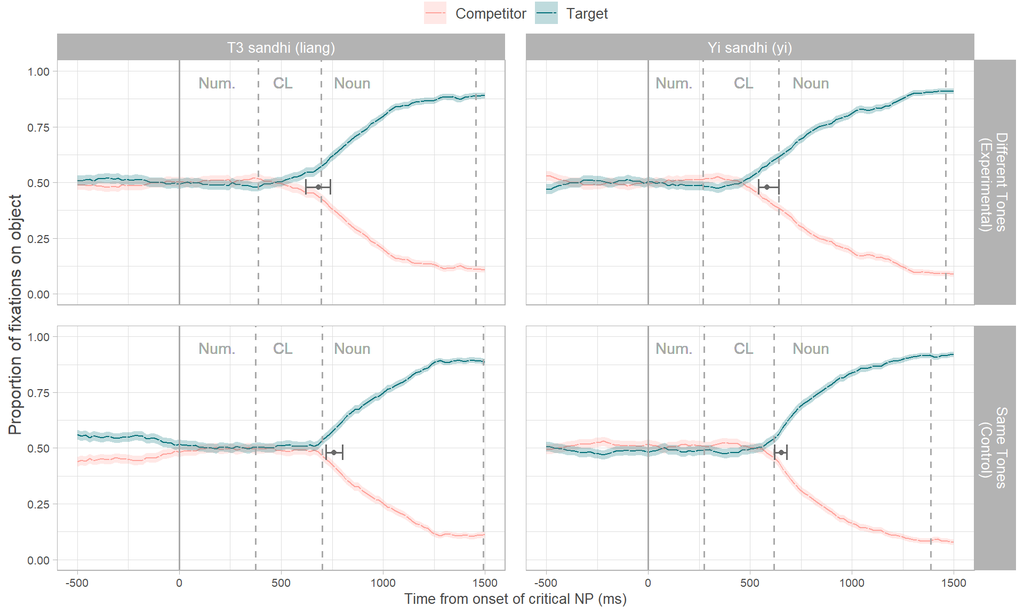

```r
# set up condition labels
cond_labs <- c("Same Tones\n (Control)","Different Tones\n (Experimental)")
names(cond_labs) <- c("same","different")
num_labs <- c("Yi sandhi (yi)","T3 sandhi (liang)")
names(num_labs) <- c('yi','liang')
# flip same and different so that both graphs have different on top, same at the bottom.
dat_plot$svd <- factor(dat_plot$svd, levels = c("different","same"))
# ggplot
(growth_plot <-
    ggplot(dat_plot, aes_string(x = "Time", y = "MeanFixation", group = "group", color = "Region", fill = "Region")) +
    facet_grid(svd ~ numeral,labeller = labeller(svd = cond_labs, numeral = num_labs)) +
    stat_summary(fun="mean",geom="line",linetype="F1") +
    stat_summary(fun.data = mean_se,geom="ribbon",alpha=0.25,colour=NA) +
    #extra elements and formatting
    theme_light() +
    coord_cartesian(ylim = c(0,1)) +
    xlab("Time from onset of critical NP (ms)") + ylab("Proportion of fixations on object") +
    scale_color_manual(values=c('#FFA29B', '#006f78'), labels=c('Competitor', 'Target')) +  #first the competitor, then the target
    scale_fill_manual(values=c('#FFA29B', '#006f78'), labels=c('Competitor', 'Target')) +
    theme(text=element_text(size=10, colour="gray28"),
          axis.title.y = element_text(size = 12),
          panel.spacing = unit(1, "lines"),
          strip.text = element_text(size = 10),
          legend.position="top",
          legend.margin=margin(0,0,0,0),
          legend.box.margin=margin(-5,-5,-5,-5),
          legend.text = element_text(size=10),
          legend.title = element_blank()) +
    #add lines indicating onset of each part of the critical phrase
    geom_vline(xintercept = 0, linewidth = 0.6, color = "darkgrey")+
    geom_vline(data = syllable_lengths, aes(xintercept = xintercept), linewidth = 0.6, color = "darkgrey", linetype = "dashed") +
    #add syllable labels for yi
    geom_text(data = subset(dat_plot, numeral=='yi'), x=127, y=0.95, label = "Num.", color = "darkgrey", hjust = "middle") +
    geom_text(data = subset(dat_plot, numeral=='yi'), x=470, y=0.95, label = "CL", color = "darkgrey", hjust = "middle") +
    geom_text(data = subset(dat_plot, numeral=='yi'), x=800, y=0.95, label = "Noun", color = "darkgrey", hjust = "middle") +
    #add syllable labels for liang
    geom_text(data = subset(dat_plot, numeral=='liang'), x=185, y=0.95, label = "Num.", color = "darkgrey", hjust = "middle") +
    geom_text(data = subset(dat_plot, numeral=='liang'), x=510, y=0.95, label = "CL", color = "darkgrey", hjust = "middle") +
    geom_text(data = subset(dat_plot, numeral=='liang'), x=850, y=0.95, label = "Noun", color = "darkgrey", hjust = "middle") +
    #add the bootstrap results for yi
    geom_point(data = subset(dat_plot, condition == "a" & numeral=='yi'),
               aes(x = (mean(bootres_yi$t[,2], na.rm = TRUE)-1)*20-200,y = .48),
               size = 1.5, colour = "#696969", show.legend =FALSE) +
    geom_errorbarh(data = subset(dat_plot, condition == "a" & numeral=='yi'),
                   aes(xmin = (boot::boot.ci(bootres_yi, index = 2,
                                             type = "perc")$perc[4]-1)*20-200,
                       xmax = (boot::boot.ci(bootres_yi, index = 2,
                                             type = "perc")$perc[5]-1)*20-200,
                       y = .48), height = .07, size = 0.7, colour = "#696969", show.legend =FALSE) +
    geom_point(data = subset(dat_plot, condition == "b" & numeral=='yi'),
               aes(x = (mean(bootres_yi$t[,3], na.rm = TRUE)-1)*20-200, y = .48),
               size = 1.5, colour = "#696969", show.legend =FALSE) +
    geom_errorbarh(data = subset(dat_plot, condition == "b" & numeral=='yi'),
                   aes(xmin = (boot::boot.ci(bootres_yi, index = 3,
                                             type = "perc")$perc[4]-1)*20-200,
                       xmax = (boot::boot.ci(bootres_yi, index = 3,
                                             type = "perc")$perc[5]-1)*20-200,
                       y = .48), height = .07, size = 0.7, colour = "#696969", show.legend =FALSE) +
    #add bootstrap results for liang
    geom_point(data = subset(dat_plot, condition == "c" & numeral=='liang'),
               aes(x = (mean(bootres_liang$t[,3], na.rm = TRUE)-1)*20-200, y = .48),
               size = 1.5, colour = "#696969", show.legend =FALSE) +
    geom_errorbarh(data = subset(dat_plot, condition == "c" & numeral=='liang'),
                   aes(xmin = (boot::boot.ci(bootres_liang, index = 3,
                                             type = "perc")$perc[4]-1)*20-200,
                       xmax = (boot::boot.ci(bootres_liang, index = 3,
                                             type = "perc")$perc[5]-1)*20-200,
                       y = .48), height = .07, size = 0.7, colour = "#696969", show.legend =FALSE) +
    geom_point(data = subset(dat_plot, condition == "d" & numeral=='liang'),
               aes(x = (mean(bootres_liang$t[,2], na.rm = TRUE)-1)*20-200, y = .48),
               size = 1.5, colour = "#696969", show.legend =FALSE) +
    geom_errorbarh(data = subset(dat_plot, condition == "d" & numeral=='liang'),
                   aes(xmin = (boot::boot.ci(bootres_liang, index = 2,
                                             type = "perc")$perc[4]-1)*20-200,
                       xmax = (boot::boot.ci(bootres_liang, index = 2,
                                             type = "perc")$perc[5]-1)*20-200,
                       y = .48), height = .07, size = 0.7, colour = "#696969", show.legend =FALSE))
```

```r
# save a pdf plot
pdf("growth_plot_written.pdf",width = 7.25, height = 3.75)
print(growth_plot)
dev.off()
```

## 3.2 Bootstrap distribution plots

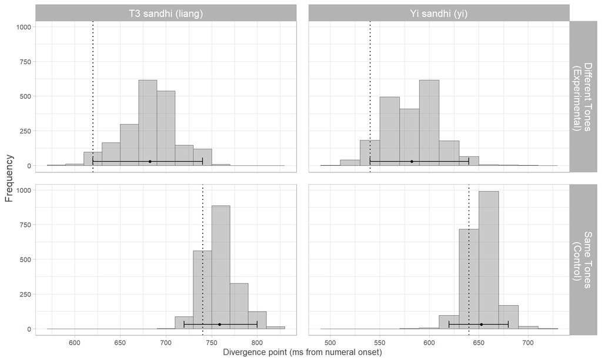

```r
# Extract bootstrap results into a dataframe
# -200 added because window of interest started at -200ms
df_yi <- as.data.frame(bootres_yi$t)  %>%
  mutate(V1 = V1*20,  # differences are relative and no need to -200ms
         V2 = (V2-1)*20-200,
         V3 = (V3-1)*20-200) %>%
  rename(delta = V1,
         same = V2,
         different = V3) %>%
  gather(key = "svd", value = "onset")

df_yi$numeral <- "yi"

df_liang <- as.data.frame(bootres_liang$t)  %>%
  mutate(V1 = V1*20,  # differences are relative and no need to -200ms
         V2 = (V2-1)*20-200,
         V3 = (V3-1)*20-200) %>%
  rename(delta = V1,
         same = V2,
         different = V3) %>%
  gather(key = "svd", value = "onset")

df_liang$numeral <- "liang"

df <- rbind(df_yi, df_liang)
df$Condition <- paste(df$numeral,"_",df$svd,sep = "")

# Order factor levels
df$Condition <- factor(df$Condition, levels = c("liang_different", "liang_same", "yi_different",
                                                "yi_same","liang_delta", "yi_delta"))
df$numeral <- factor(df$numeral, levels = c("liang","yi"))

# Plot bootstap distributions
(fig_bot_dis <- ggplot(subset(df, svd %in% c("same", "different")),
                  aes(onset)) +
    geom_histogram(binwidth = 20, fill = "grey30", colour = "grey30",
                   alpha = .3, size = 0.2) +
    # create a panel for each condition
    facet_grid(svd ~ numeral, scales = "free_x",labeller = labeller(svd = cond_labs, numeral = num_labs)) +
    # yi_same
    # add a vertical line to visualize difference between original mean
    # and bootstrap mean (i.e. bias)
    geom_vline(data = filter(df, Condition == "yi_same"),
               aes(xintercept = (mean(bootres_yi$t0[2], na.rm = TRUE)-1)*20-200),
               linetype = "dotted", size = 0.7) +
    # add point and errorbar to show mean and 95% CI
    geom_point(data = filter(df, Condition == "yi_same"),
               aes(x = (mean(bootres_yi$t[,2], na.rm = TRUE)-1)*20-200, y = 30),
               size = 1.2) +
    geom_errorbarh(data = filter(df, Condition == "yi_same"),
                   aes(xmin = (boot::boot.ci(bootres_yi, index = 2,
                                             type = "perc")$percent[4]-1)*20-200,
                       xmax = (boot::boot.ci(bootres_yi, index = 2,
                                             type = "perc")$percent[5]-1)*20-200,
                       y = 30),size = 0.4, height = 50) +
    # yi_different
    geom_vline(data = filter(df, Condition == "yi_different"),
               aes(xintercept = (mean(bootres_yi$t0[3], na.rm = TRUE)-1)*20-200),
               linetype = "dotted", size = 0.7) +
    geom_point(data = filter(df, Condition == "yi_different"),
               aes(x = (mean(bootres_yi$t[,3], na.rm = TRUE)-1)*20-200, y = 30),
               size = 1.2) +
    geom_errorbarh(data = filter(df, Condition == "yi_different"),
                   aes(xmin = (boot::boot.ci(bootres_yi, index = 3,
                                             type = "perc")$percent[4]-1)*20-200,
                       xmax = (boot::boot.ci(bootres_yi, index = 3,
                                             type = "perc")$percent[5]-1)*20-200,
                       y = 30),
                   size = 0.4, height = 50) +
    # liang_same
    geom_vline(data = filter(df, Condition == "liang_same"),
               aes(xintercept = (mean(bootres_liang$t0[2], na.rm = TRUE)-1)*20-200),
               linetype = "dotted", size = 0.7) +
    geom_point(data = filter(df, Condition == "liang_same"),
               aes(x = (mean(bootres_liang$t[,2], na.rm = TRUE)-1)*20-200, y = 30),
               size = 1.2) +
    geom_errorbarh(data = filter(df, Condition == "liang_same"),
                   aes(xmin = (boot::boot.ci(bootres_liang, index = 2,
                                             type = "perc")$percent[4]-1)*20-200,
                       xmax = (boot::boot.ci(bootres_liang, index = 2,
                                             type = "perc")$percent[5]-1)*20-200,
                       y = 30), size = 0.4, height = 50) +
    # liang_different
    geom_vline(data = filter(df, Condition == "liang_different"),
               aes(xintercept = (mean(bootres_liang$t0[3], na.rm = TRUE)-1)*20-200),
               linetype = "dotted", size = 0.7) +
    geom_point(data = filter(df, Condition == "liang_different"),
               aes(x = (mean(bootres_liang$t[,3], na.rm = TRUE)-1)*20-200, y = 30),
               size = 1.2) +
    geom_errorbarh(data = filter(df, Condition == "liang_different"),
                   aes(xmin = (boot::boot.ci(bootres_liang, index = 3,
                                             type = "perc")$percent[4]-1)*20-200,
                       xmax = (boot::boot.ci(bootres_liang, index = 3,
                                             type = "perc")$percent[5]-1)*20-200,
                       y = 30), size = 0.4, height = 50) +
    # aesthetic parameters
    labs(x = "Divergence point (ms from numeral onset)", y = "Frequency") +
    theme_light() +
    theme(text=element_text(size=10, colour="gray28"),
          axis.title.y = element_text(size = 12),
          panel.spacing = unit(1, "lines"),
          strip.text = element_text(size = 12)))
```

```r
# save a pdf plot
pdf("divergence_point_distribution_written.pdf",width = 7.25,height = 4.3)
print(fig_bot_dis)
dev.off()
```

## 3.3 Bootstrap distribution of the difference

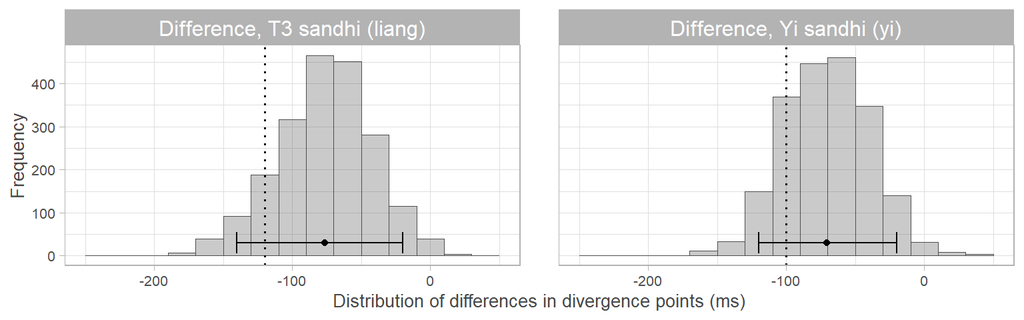

```r
# Create nicer labels
labels <- c(yi_delta = "Difference, Yi sandhi (yi)",
            liang_delta = "Difference, T3 sandhi (liang)")

# Plot distribution of difference
(fig_difference <- ggplot(subset(df, Condition %in% c("yi_delta","liang_delta")), aes(onset)) +
   geom_histogram(binwidth = 20, fill = "grey30", colour = "grey30", alpha = .3, size = 0.2) +
   # create panels for yi and liang
   facet_grid(~Condition, scales = "free", labeller = as_labeller(labels)) +
   # add vertical lines showing bias of yi
   # difference distribution
   geom_vline(data = filter(df, Condition == "yi_delta"),
              aes(xintercept = mean(bootres_yi$t0[1], na.rm = TRUE)*20),
              linetype = "dotted", size = 0.7) +
   # add point and errorbar to show mean and 95% CI
   geom_point(data = filter(df, Condition == "yi_delta"),
              aes(x = mean(bootres_yi$t[,1], na.rm = TRUE)*20, y = 30),
              size = 1.5) +
   geom_errorbarh(data = filter(df, Condition == "yi_delta"),
                  aes(xmin = boot::boot.ci(bootres_yi, index = 1,
                                            type = "perc")$percent[4]*20,
                      xmax = boot::boot.ci(bootres_yi, index = 1,
                                            type = "perc")$percent[5]*20,
                      y = 30), size = 0.5, height = 50) +
   # add vertical lines showing bias of liang
   # difference distribution
   geom_vline(data = filter(df, Condition == "liang_delta"),
              aes(xintercept = mean(bootres_liang$t0[1], na.rm = TRUE)*20),
              linetype = "dotted", size = 0.7) +
   # add point and errorbar to show mean and 95% CI
   geom_point(data = filter(df, Condition == "liang_delta"),
              aes(x = mean(bootres_liang$t[,1], na.rm = TRUE)*20, y = 30),
              size = 1.5) +
   geom_errorbarh(data = filter(df, Condition == "liang_delta"),
                  aes(xmin = boot::boot.ci(bootres_liang, index = 1,
                                            type = "perc")$percent[4]*20,
                      xmax = boot::boot.ci(bootres_liang, index = 1,
                                            type = "perc")$percent[5]*20,
                      y = 30), size = 0.5, height = 50) +
   # aesthetic parameters
   labs(x = "Distribution of differences in divergence points (ms)", y = "Frequency") +
   theme_light() +
   xlim(-250, 50) +
   theme(strip.text = element_text(size = 12),
         text = element_text(size = 10, colour="gray28"),
         panel.spacing = unit(1.5, "lines")))
```

```r
# save a pdf plot
pdf("difference_written.pdf",width = 7.25, height = 2.3)
print(fig_difference)
dev.off()
```

# 4 Bayesian principles

## 4.1 Use weak priors

(need to re-calculate the priors cause stimuli slightly differnt?)

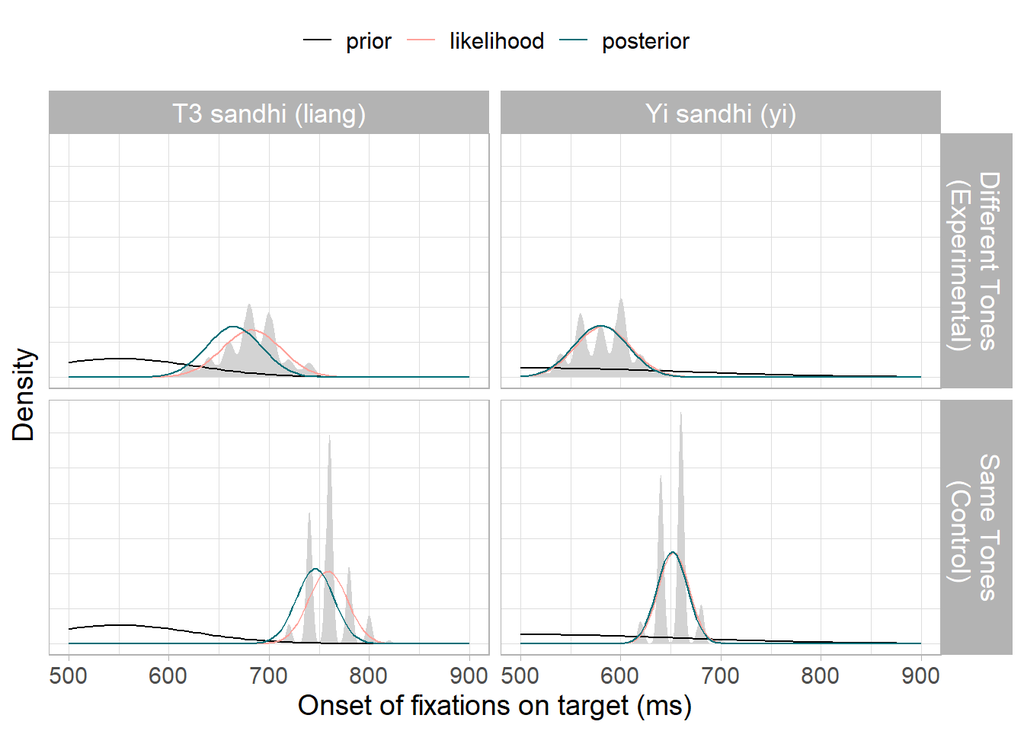

```r
# plot Bayesian yi liang together
#yi
prior_mean_same_yi <- 508
prior_sd_same_yi <- 154

prior_mean_different_yi <- 508
prior_sd_different_yi <- 154

# likelihood function
# same condition
likelihood_mean_same_yi <- mean((bootres_yi$t[,2]-1)*20-200, na.rm = TRUE)
likelihood_sd_same_yi <- sd((bootres_yi$t[,2]-1)*20-200, na.rm = TRUE) * (length(bootres_yi$t[,2])-1)/length(bootres_yi$t[,2])

# different condition
likelihood_mean_different_yi <- mean((bootres_yi$t[,3]-1)*20-200, na.rm = TRUE)
likelihood_sd_different_yi <- sd((bootres_yi$t[,3]-1)*20-200, na.rm = TRUE) * (length(bootres_yi$t[,3])-1)/length(bootres_yi$t[,3])

# posterior
# same
posterior_mean_same_yi <- ((likelihood_mean_same_yi*prior_sd_same_yi^2) + (prior_mean_same_yi*likelihood_sd_same_yi^2))/
  (prior_sd_same_yi^2 + likelihood_sd_same_yi^2)
posterior_sd_same_yi <- sqrt((likelihood_sd_same_yi^2 * prior_sd_same_yi^2) / (likelihood_sd_same_yi^2 + prior_sd_same_yi^2))

# different
posterior_mean_different_yi <- ((likelihood_mean_different_yi*prior_sd_different_yi^2) + (prior_mean_different_yi*likelihood_sd_different_yi^2))/
  (prior_sd_different_yi^2 + likelihood_sd_different_yi^2)
posterior_sd_different_yi <- sqrt((likelihood_sd_different_yi^2 * prior_sd_different_yi^2) / (likelihood_sd_different_yi^2 + prior_sd_different_yi^2))

# liang
prior_mean_same_liang <- 551
# prior_sd_same_liang <- 175.5
prior_sd_same_liang <- 75.5

prior_mean_different_liang <- 551
# prior_sd_different_liang <- 175.5
prior_sd_different_liang <- 75.5

# likelihood function
# same condition
likelihood_mean_same_liang <- mean((bootres_liang$t[,2]-1)*20-200, na.rm = TRUE)
likelihood_sd_same_liang <- sd((bootres_liang$t[,2]-1)*20-200, na.rm = TRUE) * (length(bootres_liang$t[,2])-1)/length(bootres_liang$t[,2])

# different condition
likelihood_mean_different_liang <- mean((bootres_liang$t[,3]-1)*20-200, na.rm = TRUE)
likelihood_sd_different_liang <- sd((bootres_liang$t[,3]-1)*20-200, na.rm = TRUE) * (length(bootres_liang$t[,3])-1)/length(bootres_liang$t[,3])

# posterior
# same
posterior_mean_same_liang <- ((likelihood_mean_same_liang*prior_sd_same_liang^2) + (prior_mean_same_liang*likelihood_sd_same_liang^2))/
  (prior_sd_same_liang^2 + likelihood_sd_same_liang^2)
posterior_sd_same_liang <- sqrt((likelihood_sd_same_liang^2 * prior_sd_same_liang^2) / (likelihood_sd_same_liang^2 + prior_sd_same_liang^2))

# different
posterior_mean_different_liang <- ((likelihood_mean_different_liang*prior_sd_different_liang^2) + (prior_mean_different_liang*likelihood_sd_different_liang^2))/
  (prior_sd_different_liang^2 + likelihood_sd_different_liang^2)
posterior_sd_different_liang <- sqrt((likelihood_sd_different_liang^2 * prior_sd_different_liang^2) / (likelihood_sd_different_liang^2 + prior_sd_different_liang^2))

#nicer labels
label_svd <- c("Different Tones\n (Experimental)", "Same Tones\n (Control)")
names(label_svd) <- c('different', 'same')

## plot together
dat_boot_density_plot_yi <- droplevels(subset(df_yi, svd != 'delta'))
dat_boot_density_plot_liang <- droplevels(subset(df_liang, svd != 'delta'))
dat_boot_density_plot <- rbind(dat_boot_density_plot_yi, dat_boot_density_plot_liang)
dat_boot_density_plot$numeral <- factor(dat_boot_density_plot$numeral, levels=c('liang', 'yi'))
bayesian_plot <- ggplot(dat_boot_density_plot, aes(onset)) +
  facet_grid(svd ~ numeral, labeller = labeller(svd = label_svd, numeral = num_labs)) +
  # add bootstrap results
  stat_density(aes(x=onset), geom='area', fill = 'lightgrey') +
  # add prior
  geom_function(data = subset(dat_boot_density_plot, numeral == "yi" & svd == "different"), fun=dnorm, args = list(mean=prior_mean_different_yi, sd=prior_sd_different_yi), aes(color = "1")) +
  geom_function(data = subset(dat_boot_density_plot, numeral == "yi" & svd == "same"), fun=dnorm, args = list(mean=prior_mean_same_yi, sd=prior_sd_same_yi), aes(color = "1")) +
  geom_function(data = subset(dat_boot_density_plot, numeral == "liang" & svd == "different"), fun=dnorm, args = list(mean=prior_mean_different_liang, sd=prior_sd_different_liang), aes(color = "1")) +
  geom_function(data = subset(dat_boot_density_plot, numeral == "liang" & svd == "same"), fun=dnorm, args = list(mean=prior_mean_same_liang, sd=prior_sd_same_liang), aes(color = "1")) +
  # add likelihood
  geom_function(data = subset(dat_boot_density_plot, numeral == "yi" & svd == "different"), fun=dnorm, args = list(mean=likelihood_mean_different_yi, sd=likelihood_sd_different_yi), aes(color = "2")) +
  geom_function(data = subset(dat_boot_density_plot, numeral == "yi" & svd == "same"), fun=dnorm, args = list(mean=likelihood_mean_same_yi, sd=likelihood_sd_same_yi), aes(color = "2")) +
  geom_function(data = subset(dat_boot_density_plot, numeral == "liang" & svd == "different"), fun=dnorm, args = list(mean=likelihood_mean_different_liang, sd=likelihood_sd_different_liang), aes(color = "2")) +
  geom_function(data = subset(dat_boot_density_plot, numeral == "liang" & svd == "same"), fun=dnorm, args = list(mean=likelihood_mean_same_liang, sd=likelihood_sd_same_liang), aes(color = "2")) +
  # add posterior
  geom_function(data = subset(dat_boot_density_plot, numeral == "yi" & svd == "different"), fun=dnorm, args = list(mean=posterior_mean_different_yi, sd=posterior_sd_different_yi), aes(color = "3")) +
  geom_function(data = subset(dat_boot_density_plot, numeral == "yi" & svd == "same"), fun=dnorm, args = list(mean=posterior_mean_same_yi, sd=posterior_sd_same_yi), aes(color = "3")) +
  geom_function(data = subset(dat_boot_density_plot, numeral == "liang" & svd == "different"), fun=dnorm, args = list(mean=posterior_mean_different_liang, sd=posterior_sd_different_liang), aes(color = "3")) +
  geom_function(data = subset(dat_boot_density_plot, numeral == "liang" & svd == "same"), fun=dnorm, args = list(mean=posterior_mean_same_liang, sd=posterior_sd_same_liang), aes(color = "3")) +
  # aesthetics
  scale_color_manual(labels = c('prior', 'likelihood', 'posterior'), values = c('black', '#FFA29B', '#006f78'), name = NULL) +
  xlab("Onset of fixations on target (ms)") + ylab("Density") +
  theme_light() +
  theme(text=element_text(size=14),
        axis.text.y = element_blank(),
        strip.text = element_text(size = 13),
        axis.ticks.y = element_blank(),
        legend.title = element_blank(),
        legend.position="top") +
  xlim(c(500, 900))
bayesian_plot
```

```r
pdf("Bayesian_plot-weak_written.pdf",width = 7.25, height = 4)
print(bayesian_plot)
dev.off()
```

```r
# posterior difference between same and different
posterior_mean_difference_yi  <- posterior_mean_different_yi - posterior_mean_same_yi
posterior_sd_difference_yi    <- sqrt( posterior_sd_different_yi^2 + posterior_sd_same_yi^2 )
posterior_mean_difference_liang  <- posterior_mean_different_liang - posterior_mean_same_liang
posterior_sd_difference_liang    <- sqrt( posterior_sd_different_liang^2 + posterior_sd_same_liang^2 )


# Bayes factor
# define the null hypothesis
# zero here seems to mean that we want to compare the two hypotheses (two models?) at difference = 0.
null_hypothesis <- 0

# prior difference yi
# define a prior for the distribution of differences
prior_mean_difference_yi   <- prior_mean_different_yi - prior_mean_same_yi
prior_sd_difference_yi     <- sqrt(prior_sd_different_yi^2 + prior_sd_same_yi^2)

# find the density of the prior at the null hypothesis
density_prior_null_yi     <- dnorm(null_hypothesis,
                                prior_mean_difference_yi,
                                prior_sd_difference_yi)

# find the density of the posterior at the null hypothesis
density_posterior_null_yi <- dnorm(null_hypothesis,
                                posterior_mean_difference_yi,
                                posterior_sd_difference_yi)
# prior difference liang
# define a prior for the distribution of differences
prior_mean_difference_liang   <- prior_mean_different_liang - prior_mean_same_liang
prior_sd_difference_liang     <- sqrt(prior_sd_different_liang^2 + prior_sd_same_liang^2)

# find the density of the prior at the null hypothesis
density_prior_null_liang     <- dnorm(null_hypothesis,
                                prior_mean_difference_liang,
                                prior_sd_difference_liang)

# find the density of the posterior at the null hypothesis
density_posterior_null_liang <- dnorm(null_hypothesis,
                                posterior_mean_difference_liang,
                                posterior_sd_difference_liang)

# use Savage-Dickey equation to compute the Bayes factor
(BF01_yi <- density_posterior_null_yi/density_prior_null_yi)
```

```
## [1] 0.4957254
```

```r
# compute BF10
(BF10_yi <- 1/BF01_yi)
```

```
## [1] 2.017246
```

```r
# use Savage-Dickey equation to compute the Bayes factor
(BF01_liang <- density_posterior_null_liang/density_prior_null_liang)
```

```
## [1] 0.1644263
```

```r
# compute BF10
(BF10_liang <- 1/BF01_liang)
```

```
## [1] 6.081753
```

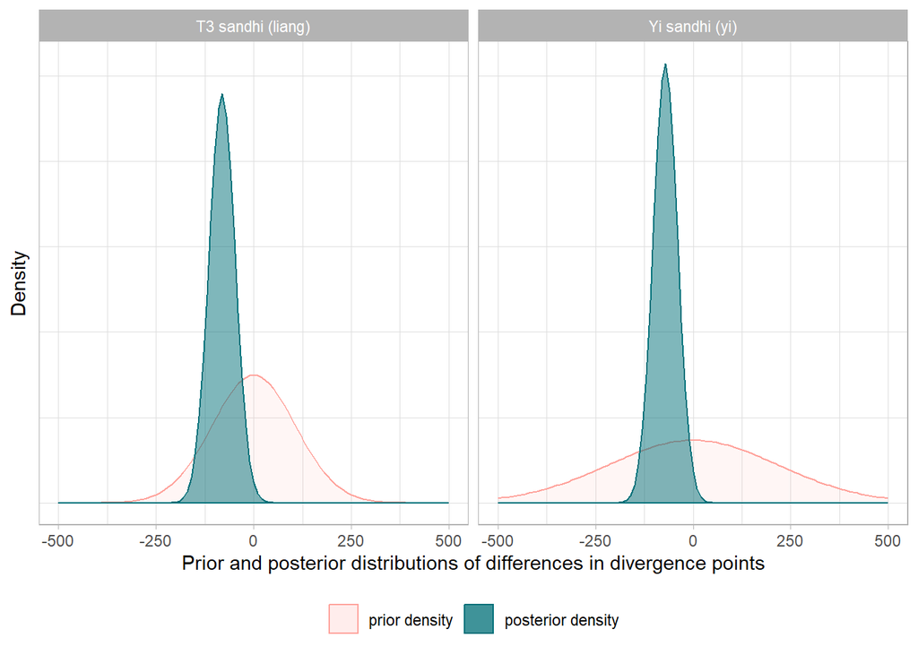

```r
df_numerals <- data.frame(num_labs)

# plot Difference
post_difference_plot_yiliang <- ggplot(df_numerals) + facet_grid(. ~ num_labs) +
  # add prior difference
  stat_function(data= subset(df_numerals, num_labs=="Yi sandhi (yi)"), fun = ~ dnorm(.x, prior_mean_difference_yi, prior_sd_difference_yi), geom = 'area', aes(color = "1", fill = "1"), alpha=0.1) +
  stat_function(data= subset(df_numerals, num_labs=="T3 sandhi (liang)"), fun = ~ dnorm(.x, prior_mean_difference_liang, prior_sd_difference_liang), geom = 'area', aes(color = "1", fill = "1"), alpha=0.1) +
  # add posterior difference
  stat_function(data= subset(df_numerals, num_labs=="Yi sandhi (yi)"), fun = ~ dnorm(.x, posterior_mean_difference_yi, posterior_sd_difference_yi), geom = 'area', aes(color = "2", fill = "2"), alpha = 0.5) +
  stat_function(data= subset(df_numerals, num_labs=="T3 sandhi (liang)"), fun = ~ dnorm(.x, posterior_mean_difference_liang, posterior_sd_difference_liang), geom = 'area', aes(color = "2", fill = "2"), alpha = 0.5) +
  # aesthetics
  scale_color_manual(labels = c('prior density', 'posterior density'), values = c('#FFA29B', '#006f78'), name = NULL) +
  scale_fill_manual(labels = c('prior density', 'posterior density'), values = c('#FFA29B', '#006f78'), name = NULL) +
  xlab("Prior and posterior distributions of differences in divergence points") + ylab("Density") +
  theme_light() +
  theme(axis.text.y = element_blank(), axis.ticks.y = element_blank(), legend.title = element_blank()) +
  theme(legend.position = "bottom") +
  xlim(c(-500, 500))
post_difference_plot_yiliang
```

```r
# pdf("Bayesian_difference_plot-weak_written.pdf",width = 7, height = 2.5)
# print(post_difference_plot_yiliang)
# dev.off()
```

```
## [1] "YI:"
```

```
## [1] "Prior chosen Same:"
```

```
## [1] "508 154"
```

```
## [1] "Prior chosen Different:"
```

```
## [1] "508 154"
```

```
## [1] "Posterior Same:"
```

```
## [1] "651.335557198325 15.1697514442929"
```

```
## [1] "Posterior Different:"
```

```
## [1] "579.97382191291 27.0208046232198"
```

```
## [1] "Posterior Difference between conditions:"
```

```
## [1] "-71.3617352854149 30.987824082498"
```

```
## [1] "Bayes Factor (BF10) (moderate support for H1 > 3):"
```

```
## [1] 2.017246
```

```
## [1] "LIANG:"
```

```
## [1] "Prior chosen Same:"
```

```
## [1] "551 75.5"
```

```
## [1] "Prior chosen Different:"
```

```
## [1] "551 75.5"
```

```
## [1] "Posterior Same:"
```

```
## [1] "746.081184817763 18.6718419293964"
```

```
## [1] "Posterior Different:"
```

```
## [1] "664.889637754672 27.5883812426011"
```

```
## [1] "Posterior Difference between conditions:"
```

```
## [1] "-81.1915470630905 33.3130073788523"
```

```
## [1] "Bayes Factor (BF10) (moderate support for H1 > 3):"
```

```
## [1] 6.081753
```

# 5 Arcsine transform window data

arcsine is used to transform binomial data. “In multivariate studies, like ordination or cluster analysis, the arcsine transformation is preferred.” because it can deal with extreme values such as 0% or 100%, unlike logit transformation which will give +-infinites.

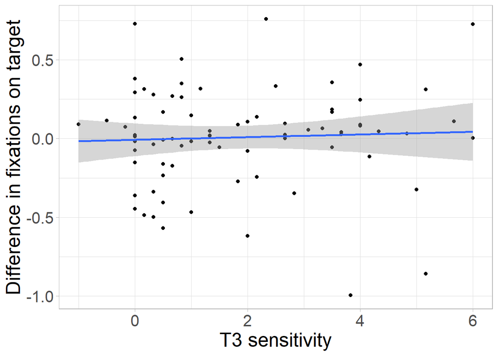

```r
t3t3 <- read.csv("t3t3_judgment.csv", header = TRUE)
names(t3t3)[names(t3t3) == "difference"] <- "T3_judgment"

# the original divergence point in real data
yi_critical_window <- mean(bootres_yi$t0[2], bootres_yi$t0[3])
liang_critical_window <- mean(bootres_liang$t0[2], bootres_liang$t0[3])

window_yi <- droplevels(subset(dat_trim_yi, Time %in% (yi_critical_window-200:yi_critical_window+200)))

window_liang <- droplevels(subset(dat_trim_liang, Time %in% (liang_critical_window-200:liang_critical_window+200)))

window_yi <- window_yi %>%
  group_by(subject, list, condition, numeral, svd) %>%
  summarise(mean = mean(target), arcsin = asin(sqrt(mean(target))))

window_liang <- window_liang %>%
  group_by(subject, list, condition, numeral, svd) %>%
  summarise(mean = mean(target), arcsin = asin(sqrt(mean(target))))

# calculate difference in arcsine
dif_yi <- window_yi %>%
  ungroup() %>%
  select(-(condition)) %>%
  pivot_wider(names_from = svd, values_from = c(arcsin, mean))
# use different - same, so that the larger the number, the more fixations on target in different (the more prediction)
dif_yi$difference_arcsin <- dif_yi$arcsin_different - dif_yi$arcsin_same
dif_yi <- merge(dif_yi, t3t3, by='subject')

dif_liang <- window_liang %>%
  ungroup() %>%
  select(-(condition)) %>%
  pivot_wider(names_from = svd, values_from = c(arcsin, mean))
dif_liang$difference_arcsin <- dif_liang$arcsin_different - dif_liang$arcsin_same
dif_liang <- merge(dif_liang, t3t3, by='subject')

# scatter plots and correlations
scatter_yi <- ggplot(dif_yi, aes(x=T3_judgment, y=difference_arcsin)) +
  geom_point() +
  geom_smooth(method=lm) +
  theme_light() +
  theme(text=element_text(size=20)) +
  xlab('T3 sensitivity') +
  ylab('Difference in fixations on target')
scatter_yi
```

```r
pdf("scatter_yi_arc_written.pdf", width = 7.25, height = 5)
print(scatter_yi)
dev.off()
```

```r
cor.test(dif_yi$T3_judgment, dif_yi$difference_arcsin, method = "pearson")
```

```
##
##  Pearson's product-moment correlation
##
## data:  dif_yi$T3_judgment and dif_yi$difference_arcsin
## t = 0.41386, df = 76, p-value = 0.6801
## alternative hypothesis: true correlation is not equal to 0
## 95 percent confidence interval:
##  -0.1769783  0.2671319
## sample estimates:
##        cor
## 0.04741999
```

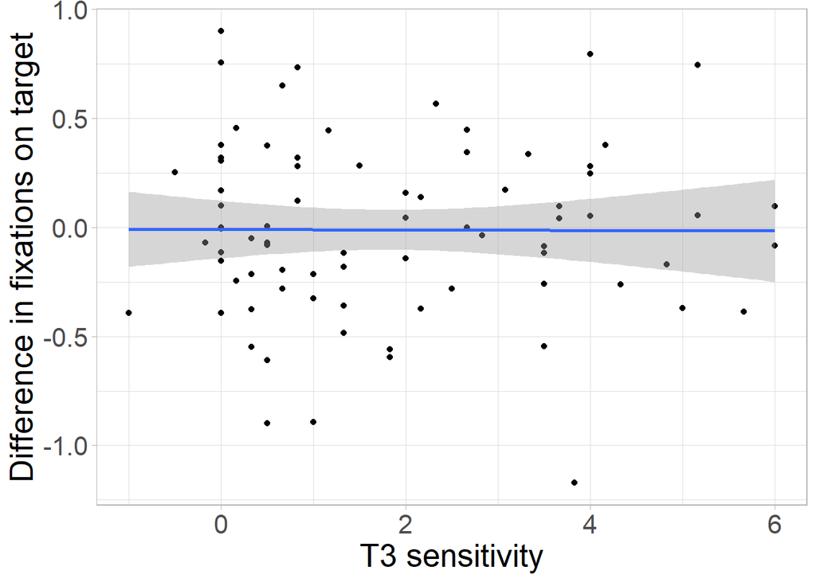

```r
scatter_liang <- ggplot(dif_liang, aes(x=T3_judgment, y=difference_arcsin)) +
  geom_point() +
  geom_smooth(method=lm) +
  theme_light() +
  theme(text=element_text(size=20)) +
  xlab('T3 sensitivity') +
  ylab('Difference in fixations on target')
scatter_liang
```

```r
pdf("scatter_liang_arc_written.pdf", width = 7.25, height = 5)
print(scatter_liang)
dev.off()
```

```r
cor.test(dif_liang$T3_judgment, dif_liang$difference_arcsin, method = "pearson")
```

```
##
##  Pearson's product-moment correlation
##
## data:  dif_liang$T3_judgment and dif_liang$difference_arcsin
## t = -0.04093, df = 76, p-value = 0.9675
## alternative hypothesis: true correlation is not equal to 0
## 95 percent confidence interval:
##  -0.2269885  0.2180637
## sample estimates:
##          cor
## -0.004694904
```